# Telecom_Churn_Prediction_week11

```python
import pandas as pd
import numpy as np
import seaborn as sns
import matplotlib.pyplot as plt
from sklearn.preprocessing import MinMaxScaler
from sklearn.model_selection import train_test_split
from sklearn.tree import DecisionTreeClassifier
from sklearn.metrics import classification_report
```

```python
import warnings
warnings.filterwarnings('ignore')
```

```python
df= pd.read_csv('telecom.csv')
df
```

|  | customerID | gender | SeniorCitizen | Partner | Dependents | tenure | PhoneService | MultipleLines | InternetService | OnlineSecurity | ... | DeviceProtection | TechSupport | StreamingTV | StreamingMovies | Contract | PaperlessBilling | PaymentMethod | MonthlyCharges | TotalCharges | Churn |
| --- | --- | --- | --- | --- | --- | --- | --- | --- | --- | --- | --- | --- | --- | --- | --- | --- | --- | --- | --- | --- | --- |
| 0 | 7590-VHVEG | Female | 0 | Yes | No | 1 | No | No phone service | DSL | No | ... | No | No | No | No | Month-to-month | Yes | Electronic check | 29.85 | 29.85 | No |
| 1 | 5575-GNVDE | Male | 0 | No | No | 34 | Yes | No | DSL | Yes | ... | Yes | No | No | No | One year | No | Mailed check | 56.95 | 1889.5 | No |
| 2 | 3668-QPYBK | Male | 0 | No | No | 2 | Yes | No | DSL | Yes | ... | No | No | No | No | Month-to-month | Yes | Mailed check | 53.85 | 108.15 | Yes |
| 3 | 7795-CFOCW | Male | 0 | No | No | 45 | No | No phone service | DSL | Yes | ... | Yes | Yes | No | No | One year | No | Bank transfer (automatic) | 42.30 | 1840.75 | No |
| 4 | 9237-HQITU | Female | 0 | No | No | 2 | Yes | No | Fiber optic | No | ... | No | No | No | No | Month-to-month | Yes | Electronic check | 70.70 | 151.65 | Yes |
| ... | ... | ... | ... | ... | ... | ... | ... | ... | ... | ... | ... | ... | ... | ... | ... | ... | ... | ... | ... | ... | ... |
| 7038 | 6840-RESVB | Male | 0 | Yes | Yes | 24 | Yes | Yes | DSL | Yes | ... | Yes | Yes | Yes | Yes | One year | Yes | Mailed check | 84.80 | 1990.5 | No |
| 7039 | 2234-XADUH | Female | 0 | Yes | Yes | 72 | Yes | Yes | Fiber optic | No | ... | Yes | No | Yes | Yes | One year | Yes | Credit card (automatic) | 103.20 | 7362.9 | No |
| 7040 | 4801-JZAZL | Female | 0 | Yes | Yes | 11 | No | No phone service | DSL | Yes | ... | No | No | No | No | Month-to-month | Yes | Electronic check | 29.60 | 346.45 | No |
| 7041 | 8361-LTMKD | Male | 1 | Yes | No | 4 | Yes | Yes | Fiber optic | No | ... | No | No | No | No | Month-to-month | Yes | Mailed check | 74.40 | 306.6 | Yes |
| 7042 | 3186-AJIEK | Male | 0 | No | No | 66 | Yes | No | Fiber optic | Yes | ... | Yes | Yes | Yes | Yes | Two year | Yes | Bank transfer (automatic) | 105.65 | 6844.5 | No |

7043 rows × 21 columns

```python
df.sample(5)
```

|  | customerID | gender | SeniorCitizen | Partner | Dependents | tenure | PhoneService | MultipleLines | InternetService | OnlineSecurity | ... | DeviceProtection | TechSupport | StreamingTV | StreamingMovies | Contract | PaperlessBilling | PaymentMethod | MonthlyCharges | TotalCharges | Churn |
| --- | --- | --- | --- | --- | --- | --- | --- | --- | --- | --- | --- | --- | --- | --- | --- | --- | --- | --- | --- | --- | --- |
| 4346 | 9351-LZYGF | Female | 0 | Yes | No | 42 | Yes | Yes | DSL | Yes | ... | No | Yes | No | No | Month-to-month | Yes | Credit card (automatic) | 66.40 | 2727.8 | No |
| 5486 | 7609-YBPXG | Male | 0 | No | No | 54 | Yes | Yes | DSL | Yes | ... | Yes | Yes | Yes | Yes | Two year | No | Bank transfer (automatic) | 87.10 | 4735.2 | No |
| 867 | 2732-ISEZX | Female | 0 | No | No | 5 | Yes | No | No | No internet service | ... | No internet service | No internet service | No internet service | No internet service | Month-to-month | Yes | Mailed check | 20.50 | 104.3 | No |
| 597 | 5172-MIGPM | Male | 0 | No | No | 4 | Yes | Yes | DSL | No | ... | No | Yes | No | Yes | Month-to-month | No | Mailed check | 65.55 | 237.2 | No |
| 5917 | 5144-PQCDZ | Male | 0 | No | No | 4 | Yes | No | No | No internet service | ... | No internet service | No internet service | No internet service | No internet service | Month-to-month | Yes | Mailed check | 19.95 | 59.25 | No |

5 rows × 21 columns

```python
df.shape
```

```
(7043, 21)
```

```python
df.info()
```

```
<class 'pandas.core.frame.DataFrame'>
RangeIndex: 7043 entries, 0 to 7042
Data columns (total 21 columns):
 #   Column            Non-Null Count  Dtype
---  ------            --------------  -----
 0   customerID        7043 non-null   object
 1   gender            7043 non-null   object
 2   SeniorCitizen     7043 non-null   int64
 3   Partner           7043 non-null   object
 4   Dependents        7043 non-null   object
 5   tenure            7043 non-null   int64
 6   PhoneService      7043 non-null   object
 7   MultipleLines     7043 non-null   object
 8   InternetService   7043 non-null   object
 9   OnlineSecurity    7043 non-null   object
 10  OnlineBackup      7043 non-null   object
 11  DeviceProtection  7043 non-null   object
 12  TechSupport       7043 non-null   object
 13  StreamingTV       7043 non-null   object
 14  StreamingMovies   7043 non-null   object
 15  Contract          7043 non-null   object
 16  PaperlessBilling  7043 non-null   object
 17  PaymentMethod     7043 non-null   object
 18  MonthlyCharges    7043 non-null   float64
 19  TotalCharges      7043 non-null   object
 20  Churn             7043 non-null   object
dtypes: float64(1), int64(2), object(18)
memory usage: 1.1+ MB
```

```python
df.columns = df.columns.str.lower()
```

```python
df.columns
```

```
Index(['customerid', 'gender', 'seniorcitizen', 'partner', 'dependents',
       'tenure', 'phoneservice', 'multiplelines', 'internetservice',
       'onlinesecurity', 'onlinebackup', 'deviceprotection', 'techsupport',
       'streamingtv', 'streamingmovies', 'contract', 'paperlessbilling',
       'paymentmethod', 'monthlycharges', 'totalcharges', 'churn'],
      dtype='object')
```

```python
df.drop(columns=['customerid'],inplace=True)
```

```python
df.columns
```

```
Index(['gender', 'seniorcitizen', 'partner', 'dependents', 'tenure',
       'phoneservice', 'multiplelines', 'internetservice', 'onlinesecurity',
       'onlinebackup', 'deviceprotection', 'techsupport', 'streamingtv',
       'streamingmovies', 'contract', 'paperlessbilling', 'paymentmethod',
       'monthlycharges', 'totalcharges', 'churn'],
      dtype='object')
```

```python
#replacing ' ' empty values with nan
df['totalcharges'] = df['totalcharges'].replace(' ', np.nan).astype(float)
```

```python
df.describe()
```

|  | seniorcitizen | tenure | monthlycharges | totalcharges |
| --- | --- | --- | --- | --- |
| count | 7043.000000 | 7043.000000 | 7043.000000 | 7032.000000 |
| mean | 0.162147 | 32.371149 | 64.761692 | 2283.300441 |
| std | 0.368612 | 24.559481 | 30.090047 | 2266.771362 |
| min | 0.000000 | 0.000000 | 18.250000 | 18.800000 |
| 25% | 0.000000 | 9.000000 | 35.500000 | 401.450000 |
| 50% | 0.000000 | 29.000000 | 70.350000 | 1397.475000 |
| 75% | 0.000000 | 55.000000 | 89.850000 | 3794.737500 |
| max | 1.000000 | 72.000000 | 118.750000 | 8684.800000 |

```python
df['churn'].value_counts()
```

```
churn
No     5174
Yes    1869
Name: count, dtype: int64
```

Data is highly imbalanced

```python
100*df['churn'].value_counts()/len(df['churn'])
```

```
churn
No     73.463013
Yes    26.536987
Name: count, dtype: float64
```

74% of the Churn data is "No" and 26% is "Yes"

```python
df.select_dtypes(include=['object']).shape
```

```
(7043, 16)
```

```python
df.select_dtypes(include=['float64','int64']).shape
```

```
(7043, 4)
```

```python
df.isnull().sum()
```

```
gender               0
seniorcitizen        0
partner              0
dependents           0
tenure               0
phoneservice         0
multiplelines        0
internetservice      0
onlinesecurity       0
onlinebackup         0
deviceprotection     0
techsupport          0
streamingtv          0
streamingmovies      0
contract             0
paperlessbilling     0
paymentmethod        0
monthlycharges       0
totalcharges        11
churn                0
dtype: int64
```

11 null values in Total Charges

```python
df.loc[df ['totalcharges'].isnull() == True]
```

|  | gender | seniorcitizen | partner | dependents | tenure | phoneservice | multiplelines | internetservice | onlinesecurity | onlinebackup | deviceprotection | techsupport | streamingtv | streamingmovies | contract | paperlessbilling | paymentmethod | monthlycharges | totalcharges | churn |
| --- | --- | --- | --- | --- | --- | --- | --- | --- | --- | --- | --- | --- | --- | --- | --- | --- | --- | --- | --- | --- |
| 488 | Female | 0 | Yes | Yes | 0 | No | No phone service | DSL | Yes | No | Yes | Yes | Yes | No | Two year | Yes | Bank transfer (automatic) | 52.55 | NaN | No |
| 753 | Male | 0 | No | Yes | 0 | Yes | No | No | No internet service | No internet service | No internet service | No internet service | No internet service | No internet service | Two year | No | Mailed check | 20.25 | NaN | No |
| 936 | Female | 0 | Yes | Yes | 0 | Yes | No | DSL | Yes | Yes | Yes | No | Yes | Yes | Two year | No | Mailed check | 80.85 | NaN | No |
| 1082 | Male | 0 | Yes | Yes | 0 | Yes | Yes | No | No internet service | No internet service | No internet service | No internet service | No internet service | No internet service | Two year | No | Mailed check | 25.75 | NaN | No |
| 1340 | Female | 0 | Yes | Yes | 0 | No | No phone service | DSL | Yes | Yes | Yes | Yes | Yes | No | Two year | No | Credit card (automatic) | 56.05 | NaN | No |
| 3331 | Male | 0 | Yes | Yes | 0 | Yes | No | No | No internet service | No internet service | No internet service | No internet service | No internet service | No internet service | Two year | No | Mailed check | 19.85 | NaN | No |
| 3826 | Male | 0 | Yes | Yes | 0 | Yes | Yes | No | No internet service | No internet service | No internet service | No internet service | No internet service | No internet service | Two year | No | Mailed check | 25.35 | NaN | No |
| 4380 | Female | 0 | Yes | Yes | 0 | Yes | No | No | No internet service | No internet service | No internet service | No internet service | No internet service | No internet service | Two year | No | Mailed check | 20.00 | NaN | No |
| 5218 | Male | 0 | Yes | Yes | 0 | Yes | No | No | No internet service | No internet service | No internet service | No internet service | No internet service | No internet service | One year | Yes | Mailed check | 19.70 | NaN | No |
| 6670 | Female | 0 | Yes | Yes | 0 | Yes | Yes | DSL | No | Yes | Yes | Yes | Yes | No | Two year | No | Mailed check | 73.35 | NaN | No |
| 6754 | Male | 0 | No | Yes | 0 | Yes | Yes | DSL | Yes | Yes | No | Yes | No | No | Two year | Yes | Bank transfer (automatic) | 61.90 | NaN | No |

```python
#missing value ratio
(11/7044)*100
```

```
0.15616127200454286
```

```python
#Removing missing values
df.dropna(how = 'any', inplace = True)
```

```python
df_updated = df.copy()
```

```python
# Get the max tenure
print(df_updated['tenure'].max())
```

```
72
```

```python
# # Group the tenure in bins of 12 months
# labels = ["{0} - {1}".format(i, i + 11) for i in range(1, 72, 12)]

# df_updated['tenure_group'] = pd.cut(df_updated.tenure, range(1, 80, 12), right=False, labels=labels)
```

```python
# df_updated['tenure_group'].value_counts()
```

```python
#null value is dropped
df.isnull().sum()
```

```
gender              0
seniorcitizen       0
partner             0
dependents          0
tenure              0
phoneservice        0
multiplelines       0
internetservice     0
onlinesecurity      0
onlinebackup        0
deviceprotection    0
techsupport         0
streamingtv         0
streamingmovies     0
contract            0
paperlessbilling    0
paymentmethod       0
monthlycharges      0
totalcharges        0
churn               0
dtype: int64
```

```python
# Check for any duplicated rows
print("\nNumber of duplicated rows before cleaning:", df.duplicated().sum())
```

```
Number of duplicated rows before cleaning: 22
```

```python
# Remove duplicated rows
df = df.drop_duplicates()
```

```python
# Check for any duplicated rows after cleaning
print("Number of duplicated rows after cleaning:", df.duplicated().sum())
```

```
Number of duplicated rows after cleaning: 0
```

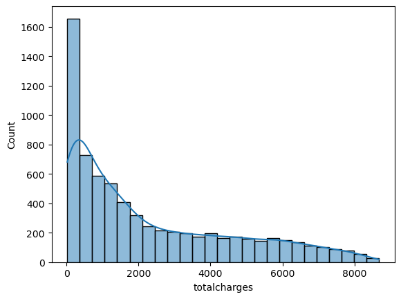

```python
sns.histplot(df['totalcharges'],kde=True)
```

The ‘totalcharges’ data is right-skewed, indicating most customers have lower charges. The distribution peaks on the left, showing a large number of customers with low charges. As charges increase, customer frequency decreases. A long tail on the right suggests a few customers have very high charges, but they are relatively rare.

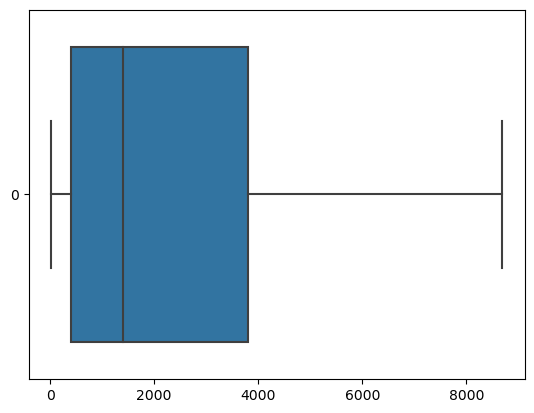

```python
sns.boxplot(df['totalcharges'],orient='h')
```

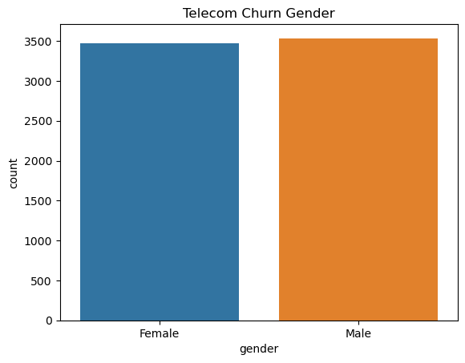

```python
sns.countplot(x = df['gender'])
plt.title('Telecom Churn Gender')
plt.show()
```

# Univariate Analysis

1. Plot distibution of individual predictors by churn

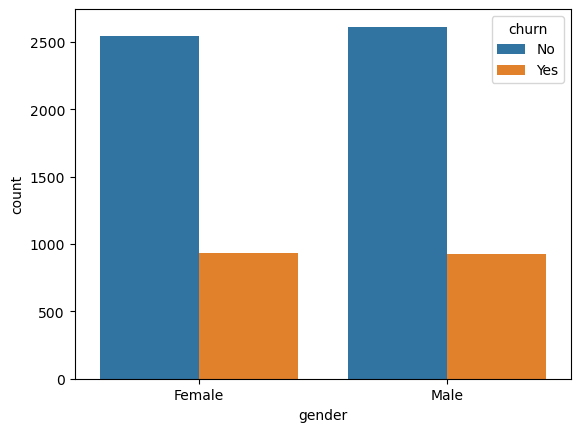

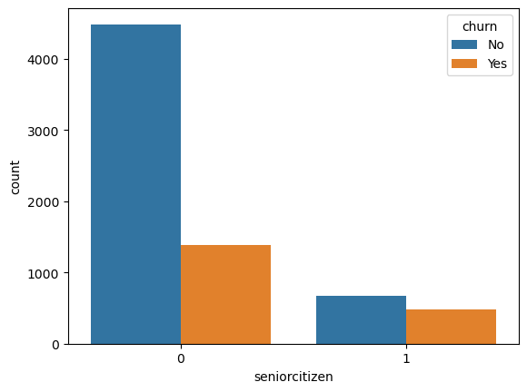

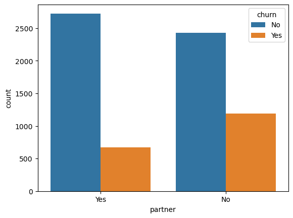

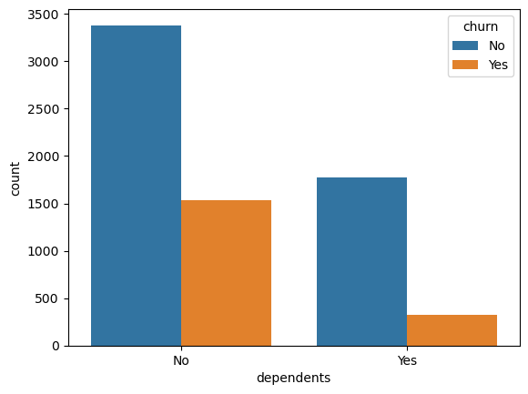

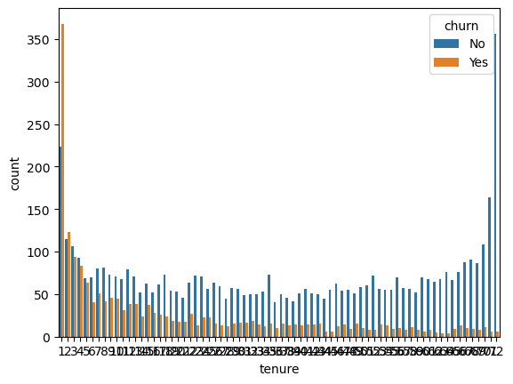

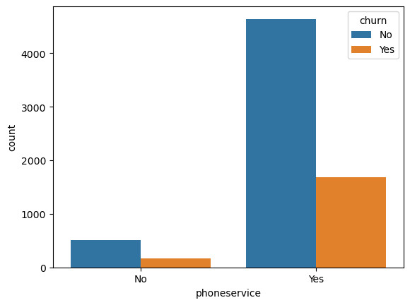

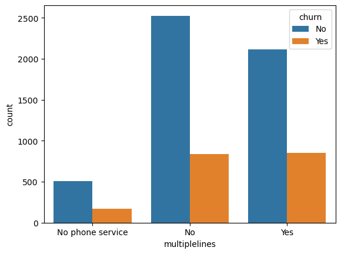

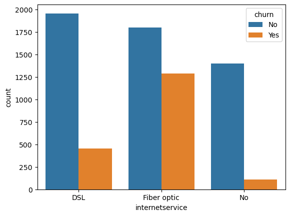

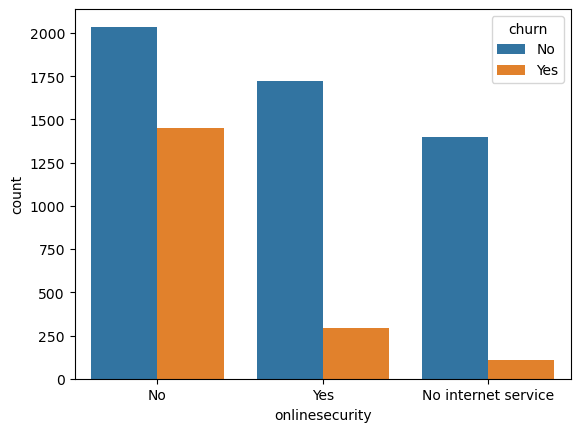

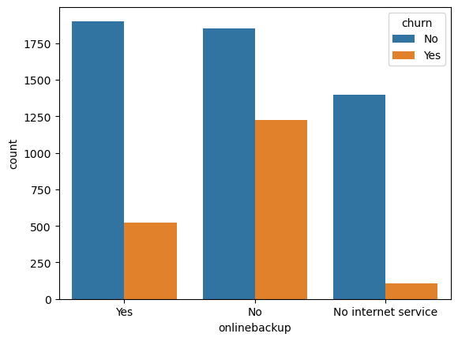

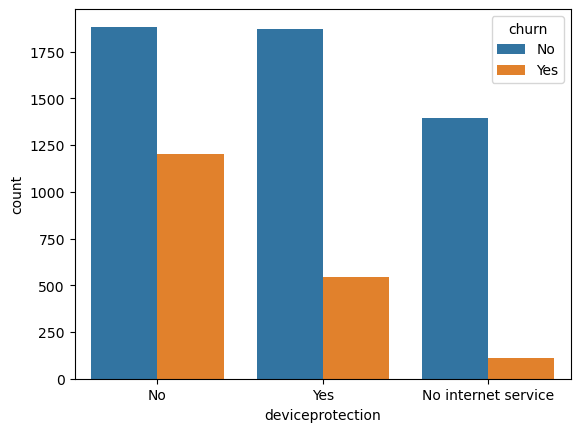

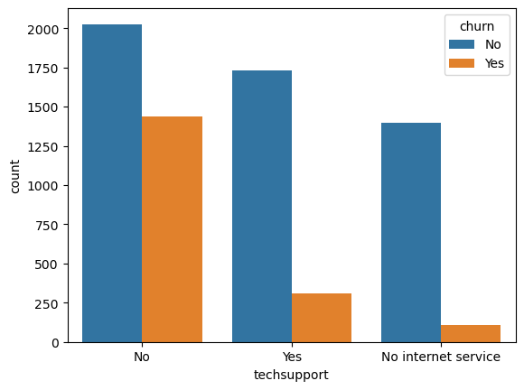

[5 more figures not shown]

```python
for i, predictor in enumerate(df.drop(columns=['churn', 'totalcharges', 'monthlycharges'])):
    plt.figure(i)
    sns.countplot(data=df, x=predictor, hue='churn')
```

1. Convert the target variable 'Churn' in a binary numeric variable i.e. Yes=1 ; No = 0

```python
df_updated['churn'] = np.where(df_updated.churn == 'Yes',1,0)
```

```python
df_updated.head()
```

|  | gender | seniorcitizen | partner | dependents | tenure | phoneservice | multiplelines | internetservice | onlinesecurity | onlinebackup | deviceprotection | techsupport | streamingtv | streamingmovies | contract | paperlessbilling | paymentmethod | monthlycharges | totalcharges | churn |
| --- | --- | --- | --- | --- | --- | --- | --- | --- | --- | --- | --- | --- | --- | --- | --- | --- | --- | --- | --- | --- |
| 0 | Female | 0 | Yes | No | 1 | No | No phone service | DSL | No | Yes | No | No | No | No | Month-to-month | Yes | Electronic check | 29.85 | 29.85 | 0 |
| 1 | Male | 0 | No | No | 34 | Yes | No | DSL | Yes | No | Yes | No | No | No | One year | No | Mailed check | 56.95 | 1889.50 | 0 |
| 2 | Male | 0 | No | No | 2 | Yes | No | DSL | Yes | Yes | No | No | No | No | Month-to-month | Yes | Mailed check | 53.85 | 108.15 | 1 |
| 3 | Male | 0 | No | No | 45 | No | No phone service | DSL | Yes | No | Yes | Yes | No | No | One year | No | Bank transfer (automatic) | 42.30 | 1840.75 | 0 |
| 4 | Female | 0 | No | No | 2 | Yes | No | Fiber optic | No | No | No | No | No | No | Month-to-month | Yes | Electronic check | 70.70 | 151.65 | 1 |

```python
# Convert all the categorical variables into dummy variables
df_updated_dummies = pd.get_dummies(df_updated)
df_updated_dummies.head()
```

|  | seniorcitizen | tenure | monthlycharges | totalcharges | churn | gender_Female | gender_Male | partner_No | partner_Yes | dependents_No | ... | streamingmovies_Yes | contract_Month-to-month | contract_One year | contract_Two year | paperlessbilling_No | paperlessbilling_Yes | paymentmethod_Bank transfer (automatic) | paymentmethod_Credit card (automatic) | paymentmethod_Electronic check | paymentmethod_Mailed check |
| --- | --- | --- | --- | --- | --- | --- | --- | --- | --- | --- | --- | --- | --- | --- | --- | --- | --- | --- | --- | --- | --- |
| 0 | 0 | 1 | 29.85 | 29.85 | 0 | True | False | False | True | True | ... | False | True | False | False | False | True | False | False | True | False |
| 1 | 0 | 34 | 56.95 | 1889.50 | 0 | False | True | True | False | True | ... | False | False | True | False | True | False | False | False | False | True |
| 2 | 0 | 2 | 53.85 | 108.15 | 1 | False | True | True | False | True | ... | False | True | False | False | False | True | False | False | False | True |
| 3 | 0 | 45 | 42.30 | 1840.75 | 0 | False | True | True | False | True | ... | False | False | True | False | True | False | True | False | False | False |
| 4 | 0 | 2 | 70.70 | 151.65 | 1 | True | False | True | False | True | ... | False | True | False | False | False | True | False | False | True | False |

5 rows × 46 columns

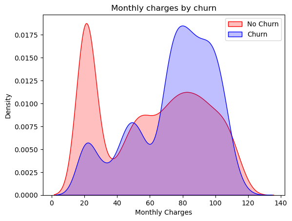

```python
# Churn by Monthly charges
Mth = sns.kdeplot(df_updated_dummies.monthlycharges[(df_updated_dummies["churn"] == 0) ],
                color="Red", shade = True)
Mth = sns.kdeplot(df_updated_dummies.monthlycharges[(df_updated_dummies["churn"] == 1) ],
                ax =Mth, color="Blue", shade= True)
Mth.legend(["No Churn","Churn"],loc='upper right')
Mth.set_ylabel('Density')
Mth.set_xlabel('Monthly Charges')
Mth.set_title('Monthly charges by churn')
```

Churn is high when Monthly Charges ar high

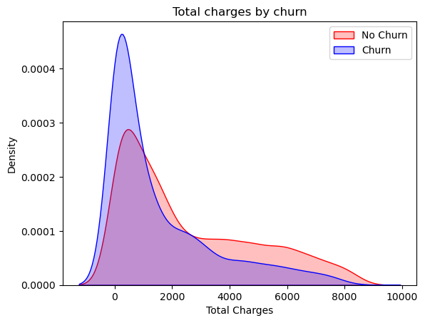

```python
# Churn by Total charges
Mth = sns.kdeplot(df_updated_dummies.totalcharges[(df_updated_dummies["churn"] == 0) ],
                color="Red", shade = True)
Mth = sns.kdeplot(df_updated_dummies.totalcharges[(df_updated_dummies["churn"] == 1) ],
                ax =Mth, color="Blue", shade= True)
Mth.legend(["No Churn","Churn"],loc='upper right')
Mth.set_ylabel('Density')
Mth.set_xlabel('Total Charges')
Mth.set_title('Total charges by churn')
```

increased Churn at reduced Total Charges Nonetheless, the picture becomes somewhat clearer when we combine the insights of the three criteria, namely tenure, monthly charges, and total charges:A higher monthly charge at a shorter tenure equals a lower total charge. Therefore, there is a correlation between high churn and all three of these factors: a higher monthly charge, a lower tenure, and a lower total charge.

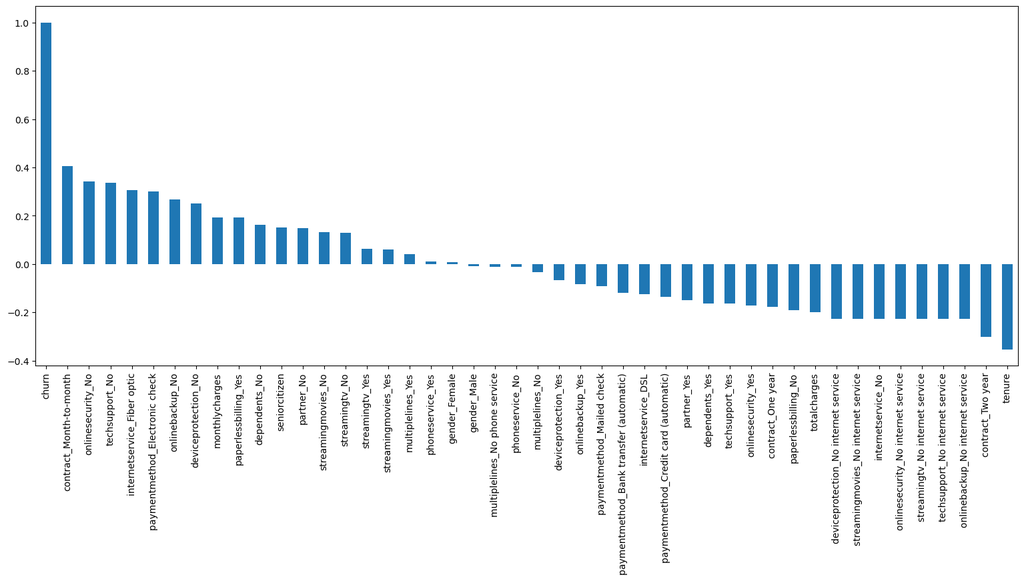

```python
plt.figure(figsize=(19,7))
df_updated_dummies.corr()['churn'].sort_values(ascending = False).plot(kind='bar')
```

HIGH Churn seen in case of Month to month contracts, No online security, No Tech support, First year of subscription and Fibre Optics Internet

LOW Churn is seens in case of Long term contracts, Subscriptions without internet service and The customers engaged for 5+ years

Factors like Gender, Availability of PhoneService and of multiple lines have alomost NO impact on Churn

This is also evident from the Heatmap below

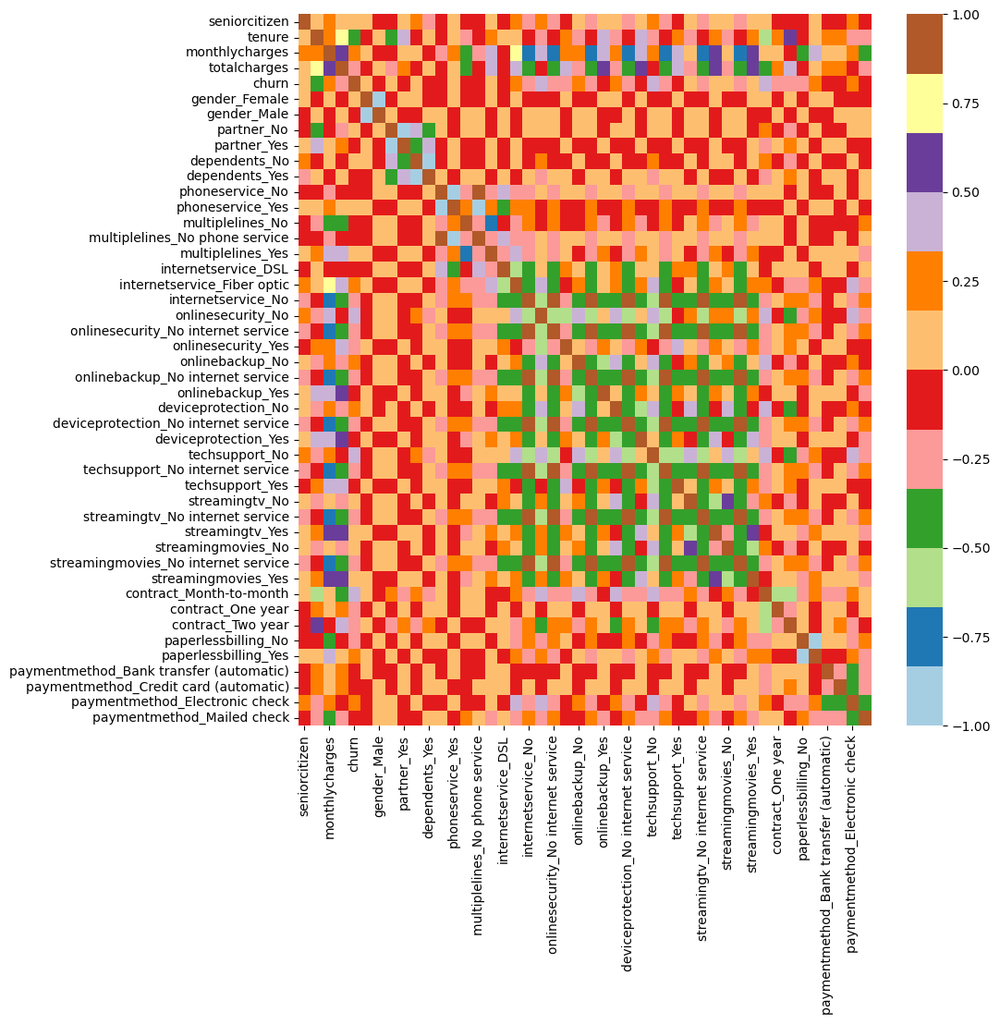

```python
plt.figure(figsize=(10,10))
sns.heatmap(df_updated_dummies.corr(), cmap="Paired")
```

# bivariate analysis

```python
new_df1_target0=df_updated.loc[df_updated["churn"]==0]
new_df1_target1=df_updated.loc[df_updated["churn"]==1]
```

```python
def uniplot(df,col,title,hue =None):

    sns.set_style('whitegrid')
    sns.set_context('talk')
    plt.rcParams["axes.labelsize"] = 20
    plt.rcParams['axes.titlesize'] = 22
    plt.rcParams['axes.titlepad'] = 30


    temp = pd.Series(data = hue)
    fig, ax = plt.subplots()
    width = len(df[col].unique()) + 7 + 4*len(temp.unique())
    fig.set_size_inches(width , 8)
    plt.xticks(rotation=45)
    plt.yscale('log')
    plt.title(title)
    ax = sns.countplot(data = df, x= col, order=df[col].value_counts().index,hue = hue,palette='bright')

    plt.show()
```

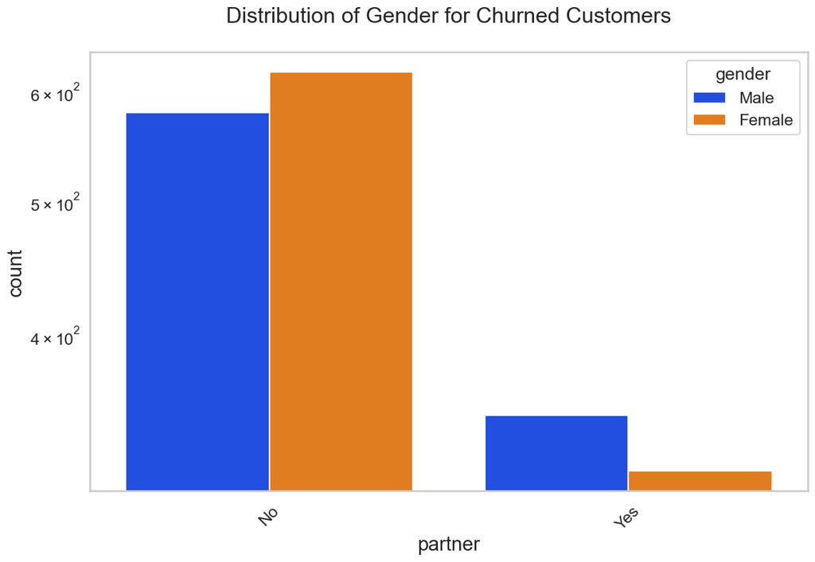

```python
uniplot(new_df1_target1,col='partner',title='Distribution of Gender for Churned Customers',hue='gender')
```

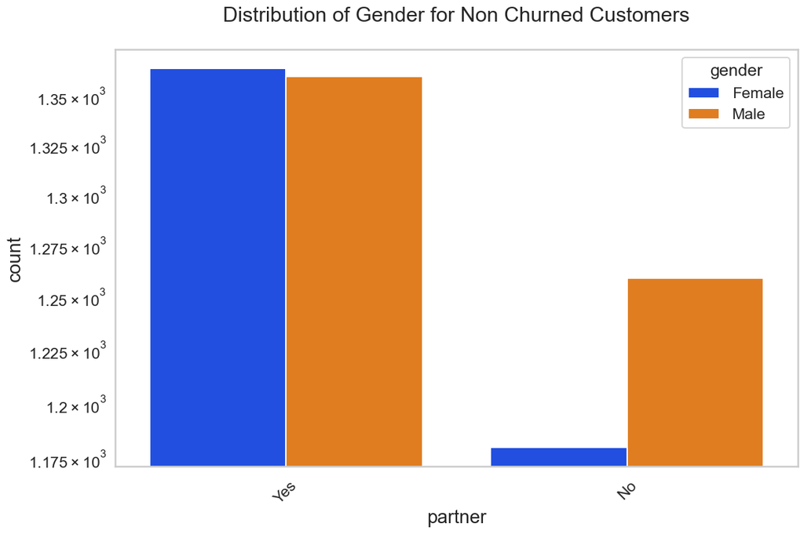

```python
uniplot(new_df1_target0,col='partner',title='Distribution of Gender for Non Churned Customers',hue='gender')
```

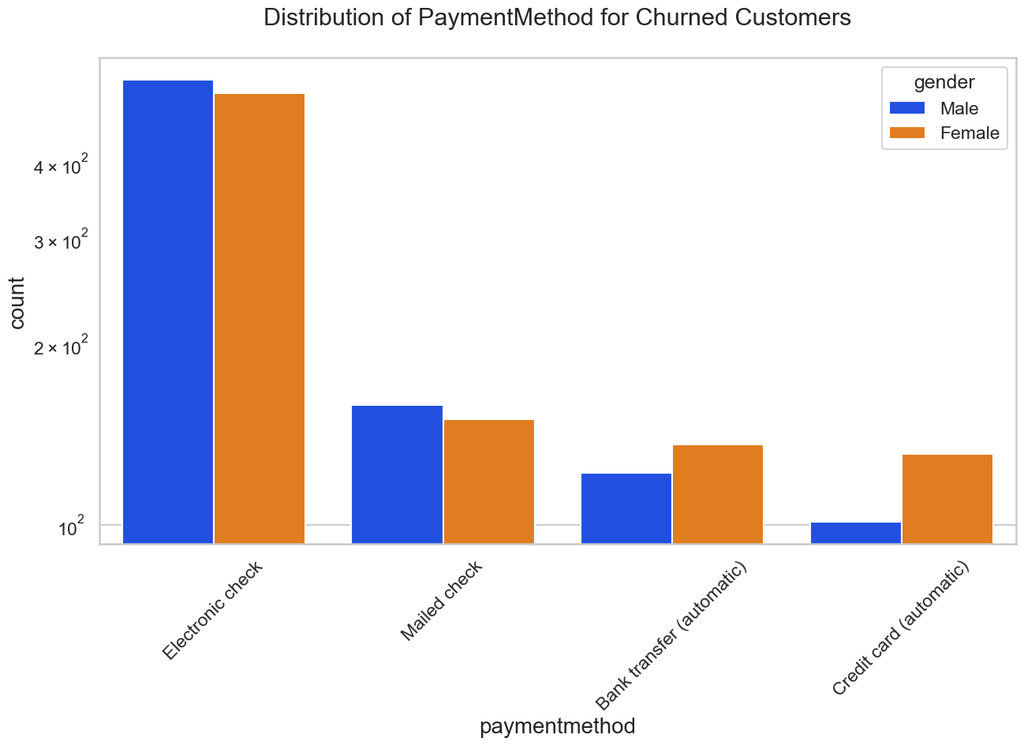

```python
uniplot(new_df1_target1,col='paymentmethod',title='Distribution of PaymentMethod for Churned Customers',hue='gender')
```

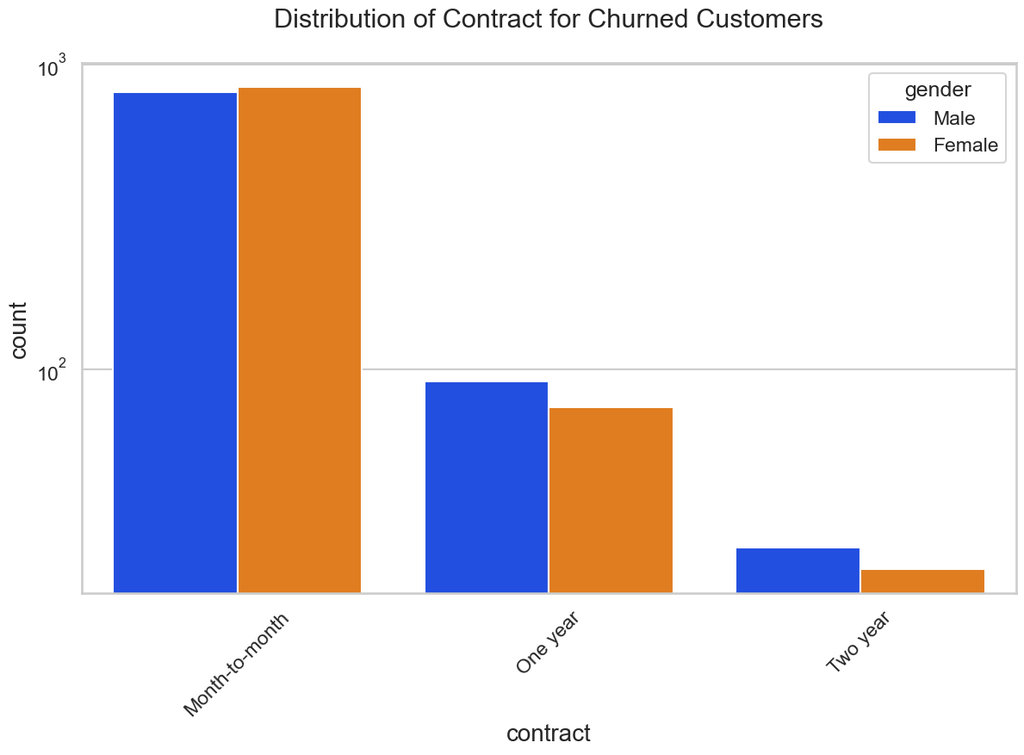

```python
uniplot(new_df1_target1,col='contract',title='Distribution of Contract for Churned Customers',hue='gender')
```

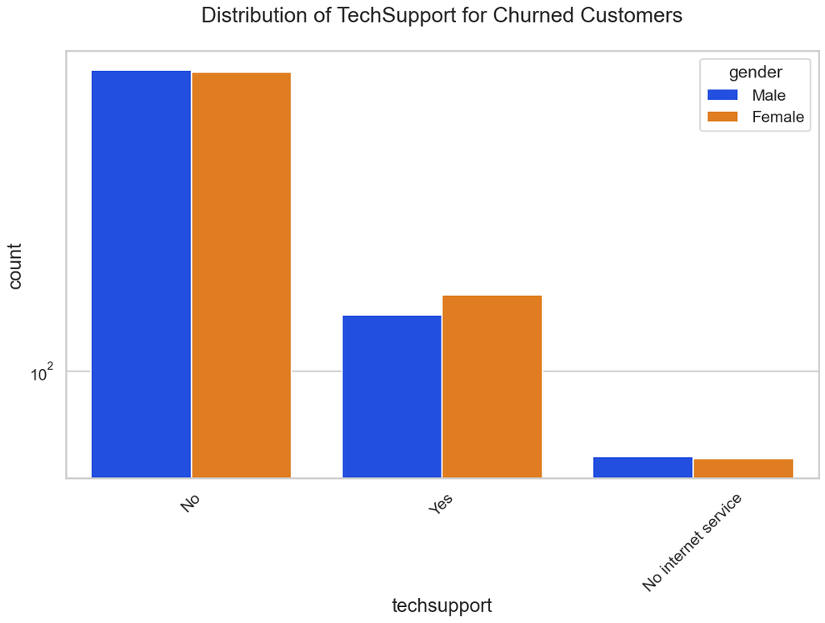

```python
uniplot(new_df1_target1,col='techsupport',title='Distribution of TechSupport for Churned Customers',hue='gender')
```

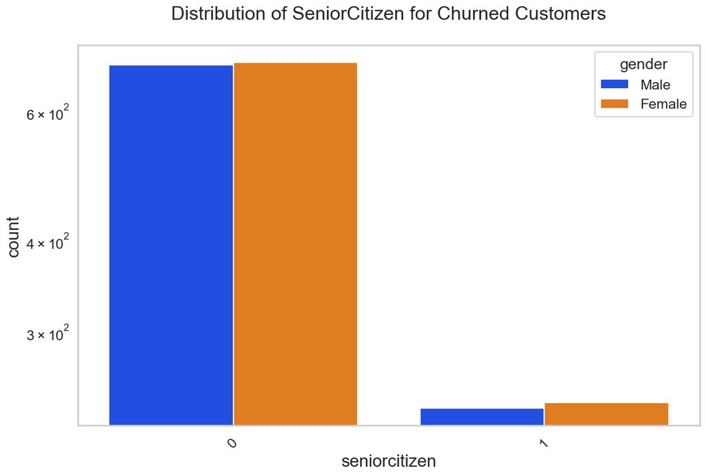

```python
uniplot(new_df1_target1,col='seniorcitizen',title='Distribution of SeniorCitizen for Churned Customers',hue='gender')
```

Electronic check medium are the highest churners

Contract Type - Monthly customers are more likely to churn because of no contract terms, as they are free to go customers.

No Online security, No Tech Support category are high churners

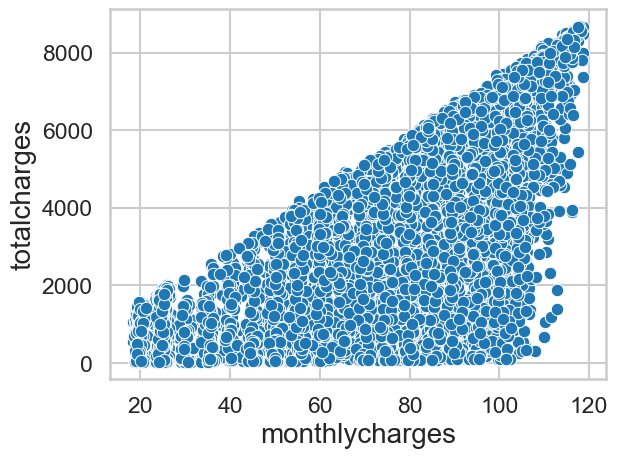

```python
sns.scatterplot(x='monthlycharges', y='totalcharges',data=df)
```

Total Charges Increase as Monthly charges Increases

```python
#selecting only categorical column
cat_cols = df.select_dtypes(include=['object']).columns
cat_cols
```

```
Index(['gender', 'partner', 'dependents', 'phoneservice', 'multiplelines',
       'internetservice', 'onlinesecurity', 'onlinebackup', 'deviceprotection',
       'techsupport', 'streamingtv', 'streamingmovies', 'contract',
       'paperlessbilling', 'paymentmethod', 'churn'],
      dtype='object')
```

```python
#dropping out target column from categorical
cat_cols = cat_cols.drop('churn')
```

```python
cat_cols
```

```
Index(['gender', 'partner', 'dependents', 'phoneservice', 'multiplelines',
       'internetservice', 'onlinesecurity', 'onlinebackup', 'deviceprotection',
       'techsupport', 'streamingtv', 'streamingmovies', 'contract',
       'paperlessbilling', 'paymentmethod'],
      dtype='object')
```

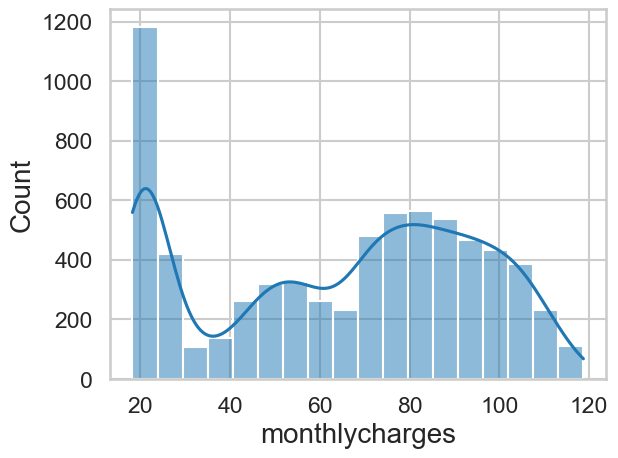

```python
sns.histplot(df['monthlycharges'],kde=True)
```

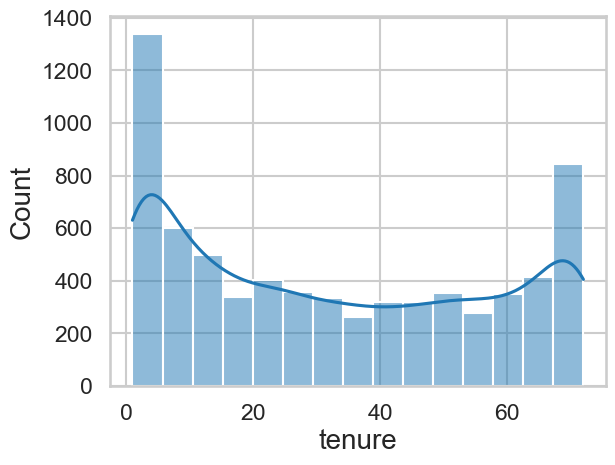

```python
sns.histplot(df['tenure'],kde=True)
```

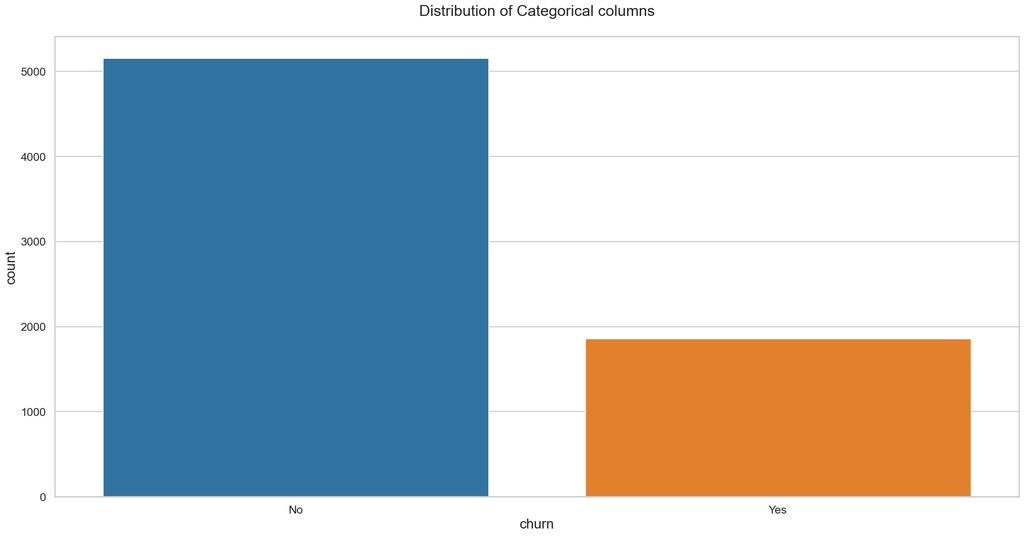

```python
# Plot count plots for categorical columns
plt.figure(figsize=(25, 12))
sns.countplot(x='churn', data=df)
plt.title('Distribution of Categorical columns')
plt.show()
```

Data is disimbalanced so we will have to balance the data later

```python
# Assuming 'Yes' is encoded as 1 and 'No' as 0 (instead of Hot-coding)
df_updated['gender'] = df_updated['gender'].replace({'Female': 0,'Male': 1})
df_updated['partner'] = df_updated['partner'].replace({'Yes': 1, 'No': 0})
df_updated['phoneservice'] = df_updated['phoneservice'].replace({'Yes': 1, 'No': 0})
df_updated['dependents'] = df_updated['dependents'].replace({'Yes': 1, 'No': 0})
df_updated['multiplelines'] = df_updated['multiplelines'].replace({'Yes': 1, 'No': 0, 'No phone service':2})
df_updated['internetservice'] = df_updated['internetservice'].replace({'DSL': 1, 'Fiber optic': 2,'No':0})
df_updated['onlinesecurity'] = df_updated['onlinesecurity'].replace({'Yes': 1, 'No': 0, 'No internet service': 0})
df_updated['onlinebackup'] = df_updated['onlinebackup'].replace({'Yes': 1, 'No': 0, 'No internet service': 0})
df_updated['deviceprotection'] = df_updated['deviceprotection'].replace({'Yes': 1, 'No': 0, 'No internet service': 0})
df_updated['techsupport'] = df_updated['techsupport'].replace({'Yes': 1, 'No': 0, 'No internet service': 0})
df_updated['streamingtv'] = df_updated['streamingtv'].replace({'Yes': 1, 'No': 0, 'No internet service': 0})
df_updated['streamingmovies'] = df_updated['streamingmovies'].replace({'Yes': 1, 'No': 0, 'No internet service': 0})
df_updated['contract'] = df_updated['contract'].replace({'Month-to-month': 1, 'One year': 0, 'Two year': 0})
df_updated['paperlessbilling'] = df_updated['paperlessbilling'].replace({'Yes': 1, 'No': 0})
df_updated['paymentmethod'] = df_updated['paymentmethod'].replace({'Electronic check': 1, 'Mailed check': 0, 'Bank transfer (automatic)':2,'Credit card (automatic)':3})
df_updated['churn'] = df_updated['churn'].replace({'Yes': 1, 'No': 0})
```

```python
df_updated.sample(10)
```

|  | gender | seniorcitizen | partner | dependents | tenure | phoneservice | multiplelines | internetservice | onlinesecurity | onlinebackup | deviceprotection | techsupport | streamingtv | streamingmovies | contract | paperlessbilling | paymentmethod | monthlycharges | totalcharges | churn |
| --- | --- | --- | --- | --- | --- | --- | --- | --- | --- | --- | --- | --- | --- | --- | --- | --- | --- | --- | --- | --- |
| 184 | 0 | 0 | 0 | 0 | 13 | 1 | 0 | 2 | 0 | 1 | 1 | 0 | 0 | 0 | 1 | 1 | 1 | 79.25 | 1111.65 | 1 |
| 5149 | 0 | 0 | 0 | 0 | 62 | 1 | 0 | 0 | 0 | 0 | 0 | 0 | 0 | 0 | 0 | 1 | 3 | 19.20 | 1123.65 | 0 |
| 769 | 1 | 0 | 1 | 0 | 17 | 1 | 0 | 1 | 1 | 1 | 0 | 0 | 0 | 1 | 0 | 0 | 0 | 64.80 | 1175.60 | 0 |
| 3617 | 0 | 1 | 1 | 0 | 18 | 0 | 2 | 1 | 0 | 0 | 1 | 0 | 1 | 1 | 1 | 1 | 1 | 48.35 | 810.70 | 1 |
| 3358 | 1 | 0 | 0 | 0 | 27 | 1 | 0 | 1 | 1 | 0 | 0 | 1 | 0 | 0 | 1 | 0 | 0 | 53.45 | 1461.45 | 0 |
| 6137 | 0 | 0 | 0 | 0 | 5 | 1 | 0 | 1 | 1 | 0 | 0 | 1 | 0 | 0 | 1 | 0 | 3 | 53.85 | 259.80 | 1 |
| 2742 | 1 | 0 | 0 | 0 | 66 | 1 | 1 | 1 | 1 | 1 | 1 | 1 | 0 | 0 | 0 | 0 | 2 | 68.75 | 4447.55 | 0 |
| 1109 | 1 | 0 | 1 | 0 | 40 | 1 | 0 | 1 | 0 | 1 | 0 | 0 | 0 | 0 | 1 | 1 | 0 | 50.15 | 2058.50 | 0 |
| 1390 | 0 | 0 | 1 | 1 | 72 | 1 | 0 | 1 | 1 | 1 | 1 | 0 | 0 | 1 | 0 | 0 | 3 | 68.75 | 4888.20 | 0 |
| 4977 | 1 | 0 | 1 | 1 | 24 | 1 | 0 | 0 | 0 | 0 | 0 | 0 | 0 | 0 | 0 | 1 | 3 | 20.80 | 469.65 | 0 |

```python
df.tenure.describe()
```

```
count    7010.000000
mean       32.520399
std        24.520441
min         1.000000
25%         9.000000
50%        29.000000
75%        56.000000
max        72.000000
Name: tenure, dtype: float64
```

```python
df.select_dtypes(include=['object']).columns
```

```
Index(['gender', 'partner', 'dependents', 'phoneservice', 'multiplelines',
       'internetservice', 'onlinesecurity', 'onlinebackup', 'deviceprotection',
       'techsupport', 'streamingtv', 'streamingmovies', 'contract',
       'paperlessbilling', 'paymentmethod', 'churn'],
      dtype='object')
```

```python
df.churn.unique()
```

```
array(['No', 'Yes'], dtype=object)
```

```python
# Calculate correlation matrix
correlation_matrix = df_updated[['phoneservice', 'multiplelines', 'internetservice', 'churn']].corr()
```

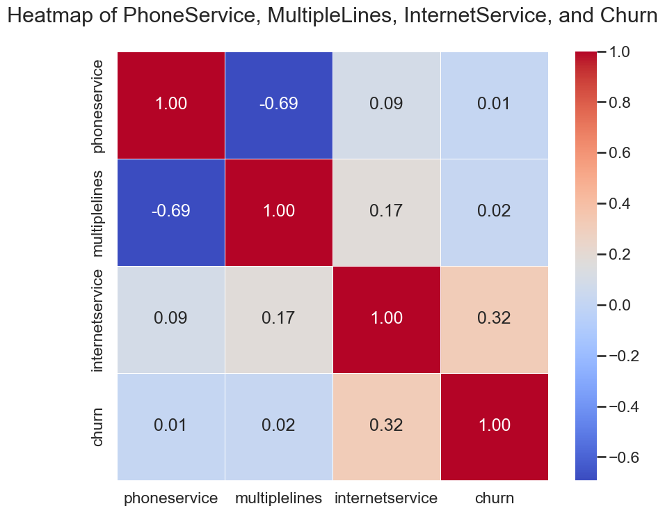

```python
# Create heatmap
plt.figure(figsize=(10, 8))
sns.heatmap(correlation_matrix, annot=True, cmap='coolwarm', fmt=".2f", linewidths=0.5)
plt.title('Heatmap of PhoneService, MultipleLines, InternetService, and Churn')
plt.show()
```

```python
# Calculate correlation matrix
correlation_matrix_cats = df_updated[['gender', 'partner', 'dependents', 'phoneservice', 'multiplelines',
       'internetservice', 'onlinesecurity', 'onlinebackup', 'deviceprotection',
       'techsupport', 'streamingtv', 'streamingmovies', 'contract',
       'paperlessbilling', 'paymentmethod', 'churn']].corr()
```

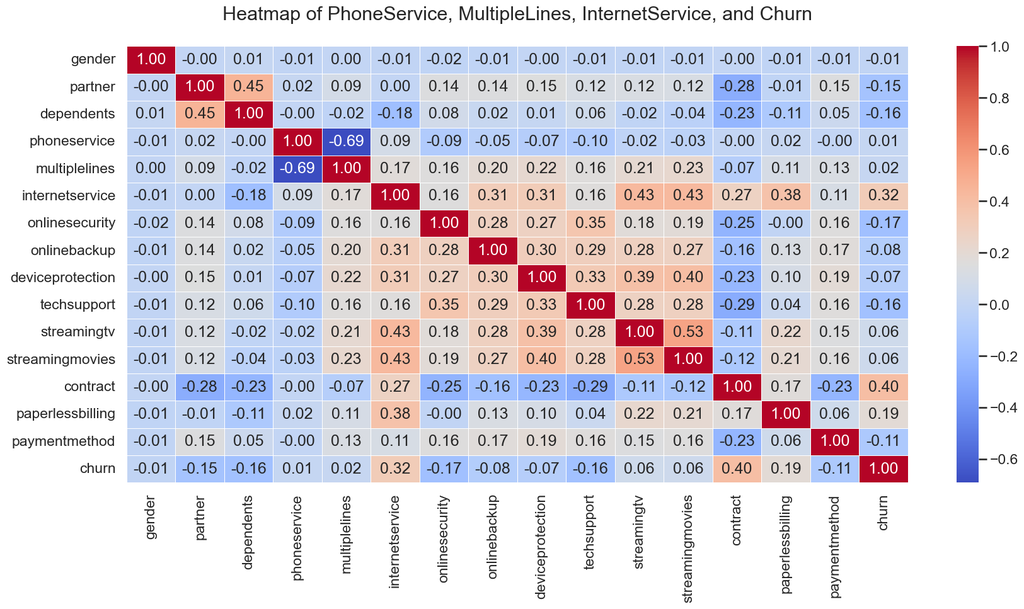

```python
# Create heatmap for categorical data
plt.figure(figsize=(20, 9))
sns.heatmap(correlation_matrix_cats, annot=True, cmap='coolwarm', fmt=".2f", linewidths=0.5)
plt.title('Heatmap of PhoneService, MultipleLines, InternetService, and Churn')
plt.show()
```

```python
num_cols = df.select_dtypes(include=['float64', 'int64','int32']).columns
for column in num_cols:
    unique_values = df[column].unique()
    print(f"Column '{column}': {unique_values}")
```

```
Column 'seniorcitizen': [0 1]
Column 'tenure': [ 1 34  2 45  8 22 10 28 62 13 16 58 49 25 69 52 71 21 12 30 47 72 17 27
  5 46 11 70 63 43 15 60 18 66  9  3 31 50 64 56  7 42 35 48 29 65 38 68
 32 55 37 36 41  6  4 33 67 23 57 61 14 20 53 40 59 24 44 19 54 51 26 39]
Column 'monthlycharges': [29.85 56.95 53.85 ... 63.1  44.2  78.7 ]
Column 'totalcharges': [  29.85 1889.5   108.15 ...  346.45  306.6  6844.5 ]
```

```python
# Assigning feature variable to X
x = df_updated.drop(['churn'], axis=1)

x.head()
```

|  | gender | seniorcitizen | partner | dependents | tenure | phoneservice | multiplelines | internetservice | onlinesecurity | onlinebackup | deviceprotection | techsupport | streamingtv | streamingmovies | contract | paperlessbilling | paymentmethod | monthlycharges | totalcharges |
| --- | --- | --- | --- | --- | --- | --- | --- | --- | --- | --- | --- | --- | --- | --- | --- | --- | --- | --- | --- |
| 0 | 0 | 0 | 1 | 0 | 1 | 0 | 2 | 1 | 0 | 1 | 0 | 0 | 0 | 0 | 1 | 1 | 1 | 29.85 | 29.85 |
| 1 | 1 | 0 | 0 | 0 | 34 | 1 | 0 | 1 | 1 | 0 | 1 | 0 | 0 | 0 | 0 | 0 | 0 | 56.95 | 1889.50 |
| 2 | 1 | 0 | 0 | 0 | 2 | 1 | 0 | 1 | 1 | 1 | 0 | 0 | 0 | 0 | 1 | 1 | 0 | 53.85 | 108.15 |
| 3 | 1 | 0 | 0 | 0 | 45 | 0 | 2 | 1 | 1 | 0 | 1 | 1 | 0 | 0 | 0 | 0 | 2 | 42.30 | 1840.75 |
| 4 | 0 | 0 | 0 | 0 | 2 | 1 | 0 | 2 | 0 | 0 | 0 | 0 | 0 | 0 | 1 | 1 | 1 | 70.70 | 151.65 |

```python
y = df_updated['churn']

y.head()
```

```
0    0
1    0
2    1
3    0
4    1
Name: churn, dtype: int32
```

# Train Test Split

```python
#selecting only totalcharges column to apply imputation by mean which contains null values
impute_cols = df[['totalcharges']].columns
impute_cols
```

```
Index(['totalcharges'], dtype='object')
```

```python
df
```

|  | gender | seniorcitizen | partner | dependents | tenure | phoneservice | multiplelines | internetservice | onlinesecurity | onlinebackup | deviceprotection | techsupport | streamingtv | streamingmovies | contract | paperlessbilling | paymentmethod | monthlycharges | totalcharges | churn |
| --- | --- | --- | --- | --- | --- | --- | --- | --- | --- | --- | --- | --- | --- | --- | --- | --- | --- | --- | --- | --- |
| 0 | Female | 0 | Yes | No | 1 | No | No phone service | DSL | No | Yes | No | No | No | No | Month-to-month | Yes | Electronic check | 29.85 | 29.85 | No |
| 1 | Male | 0 | No | No | 34 | Yes | No | DSL | Yes | No | Yes | No | No | No | One year | No | Mailed check | 56.95 | 1889.50 | No |
| 2 | Male | 0 | No | No | 2 | Yes | No | DSL | Yes | Yes | No | No | No | No | Month-to-month | Yes | Mailed check | 53.85 | 108.15 | Yes |
| 3 | Male | 0 | No | No | 45 | No | No phone service | DSL | Yes | No | Yes | Yes | No | No | One year | No | Bank transfer (automatic) | 42.30 | 1840.75 | No |
| 4 | Female | 0 | No | No | 2 | Yes | No | Fiber optic | No | No | No | No | No | No | Month-to-month | Yes | Electronic check | 70.70 | 151.65 | Yes |
| ... | ... | ... | ... | ... | ... | ... | ... | ... | ... | ... | ... | ... | ... | ... | ... | ... | ... | ... | ... | ... |
| 7038 | Male | 0 | Yes | Yes | 24 | Yes | Yes | DSL | Yes | No | Yes | Yes | Yes | Yes | One year | Yes | Mailed check | 84.80 | 1990.50 | No |
| 7039 | Female | 0 | Yes | Yes | 72 | Yes | Yes | Fiber optic | No | Yes | Yes | No | Yes | Yes | One year | Yes | Credit card (automatic) | 103.20 | 7362.90 | No |
| 7040 | Female | 0 | Yes | Yes | 11 | No | No phone service | DSL | Yes | No | No | No | No | No | Month-to-month | Yes | Electronic check | 29.60 | 346.45 | No |
| 7041 | Male | 1 | Yes | No | 4 | Yes | Yes | Fiber optic | No | No | No | No | No | No | Month-to-month | Yes | Mailed check | 74.40 | 306.60 | Yes |
| 7042 | Male | 0 | No | No | 66 | Yes | No | Fiber optic | Yes | No | Yes | Yes | Yes | Yes | Two year | Yes | Bank transfer (automatic) | 105.65 | 6844.50 | No |

7010 rows × 20 columns

```python
#selecting independent column
X = df.iloc[:,:-1]
X
```

|  | gender | seniorcitizen | partner | dependents | tenure | phoneservice | multiplelines | internetservice | onlinesecurity | onlinebackup | deviceprotection | techsupport | streamingtv | streamingmovies | contract | paperlessbilling | paymentmethod | monthlycharges | totalcharges |
| --- | --- | --- | --- | --- | --- | --- | --- | --- | --- | --- | --- | --- | --- | --- | --- | --- | --- | --- | --- |
| 0 | Female | 0 | Yes | No | 1 | No | No phone service | DSL | No | Yes | No | No | No | No | Month-to-month | Yes | Electronic check | 29.85 | 29.85 |
| 1 | Male | 0 | No | No | 34 | Yes | No | DSL | Yes | No | Yes | No | No | No | One year | No | Mailed check | 56.95 | 1889.50 |
| 2 | Male | 0 | No | No | 2 | Yes | No | DSL | Yes | Yes | No | No | No | No | Month-to-month | Yes | Mailed check | 53.85 | 108.15 |
| 3 | Male | 0 | No | No | 45 | No | No phone service | DSL | Yes | No | Yes | Yes | No | No | One year | No | Bank transfer (automatic) | 42.30 | 1840.75 |
| 4 | Female | 0 | No | No | 2 | Yes | No | Fiber optic | No | No | No | No | No | No | Month-to-month | Yes | Electronic check | 70.70 | 151.65 |
| ... | ... | ... | ... | ... | ... | ... | ... | ... | ... | ... | ... | ... | ... | ... | ... | ... | ... | ... | ... |
| 7038 | Male | 0 | Yes | Yes | 24 | Yes | Yes | DSL | Yes | No | Yes | Yes | Yes | Yes | One year | Yes | Mailed check | 84.80 | 1990.50 |
| 7039 | Female | 0 | Yes | Yes | 72 | Yes | Yes | Fiber optic | No | Yes | Yes | No | Yes | Yes | One year | Yes | Credit card (automatic) | 103.20 | 7362.90 |
| 7040 | Female | 0 | Yes | Yes | 11 | No | No phone service | DSL | Yes | No | No | No | No | No | Month-to-month | Yes | Electronic check | 29.60 | 346.45 |
| 7041 | Male | 1 | Yes | No | 4 | Yes | Yes | Fiber optic | No | No | No | No | No | No | Month-to-month | Yes | Mailed check | 74.40 | 306.60 |
| 7042 | Male | 0 | No | No | 66 | Yes | No | Fiber optic | Yes | No | Yes | Yes | Yes | Yes | Two year | Yes | Bank transfer (automatic) | 105.65 | 6844.50 |

7010 rows × 19 columns

```python
#selecting dependent column
y = df.iloc[:,-1:]
y
```

|  | churn |
| --- | --- |
| 0 | No |
| 1 | No |
| 2 | Yes |
| 3 | No |
| 4 | Yes |
| ... | ... |
| 7038 | No |
| 7039 | No |
| 7040 | No |
| 7041 | Yes |
| 7042 | No |

7010 rows × 1 columns

```python
#splitting data into train and test, testing data contains 20%
from sklearn.model_selection import train_test_split
X_train,X_test,y_train,y_test = train_test_split(X,y,test_size=0.2,random_state=42)
```

```python
X_train
```

|  | gender | seniorcitizen | partner | dependents | tenure | phoneservice | multiplelines | internetservice | onlinesecurity | onlinebackup | deviceprotection | techsupport | streamingtv | streamingmovies | contract | paperlessbilling | paymentmethod | monthlycharges | totalcharges |
| --- | --- | --- | --- | --- | --- | --- | --- | --- | --- | --- | --- | --- | --- | --- | --- | --- | --- | --- | --- |
| 1328 | Female | 0 | Yes | No | 23 | Yes | No | DSL | No | No | Yes | Yes | No | No | Month-to-month | No | Electronic check | 54.25 | 1221.55 |
| 5716 | Male | 0 | No | Yes | 2 | Yes | No | DSL | No | No | No | No | No | Yes | Month-to-month | Yes | Electronic check | 55.30 | 108.65 |
| 1906 | Male | 0 | No | No | 40 | No | No phone service | DSL | No | Yes | No | Yes | No | No | One year | No | Credit card (automatic) | 36.00 | 1382.90 |
| 6687 | Female | 1 | Yes | No | 2 | Yes | Yes | Fiber optic | No | No | Yes | No | No | No | Month-to-month | No | Electronic check | 79.20 | 172.85 |
| 1880 | Male | 0 | No | No | 2 | Yes | Yes | Fiber optic | No | No | No | No | No | Yes | Month-to-month | Yes | Electronic check | 86.00 | 165.45 |
| ... | ... | ... | ... | ... | ... | ... | ... | ... | ... | ... | ... | ... | ... | ... | ... | ... | ... | ... | ... |
| 3787 | Female | 0 | No | No | 58 | Yes | No | Fiber optic | No | No | No | Yes | Yes | Yes | Month-to-month | Yes | Electronic check | 95.30 | 5817.70 |
| 5210 | Male | 0 | Yes | No | 53 | No | No phone service | DSL | No | Yes | Yes | Yes | Yes | Yes | One year | Yes | Electronic check | 60.45 | 3184.25 |
| 5246 | Female | 0 | No | No | 2 | Yes | No | Fiber optic | No | No | No | No | Yes | No | Month-to-month | Yes | Electronic check | 79.75 | 164.50 |
| 5410 | Female | 0 | Yes | No | 64 | Yes | No | Fiber optic | Yes | No | Yes | No | Yes | Yes | Two year | Yes | Bank transfer (automatic) | 99.00 | 6375.80 |
| 862 | Male | 1 | Yes | No | 20 | Yes | No | Fiber optic | No | Yes | No | No | No | No | Month-to-month | Yes | Electronic check | 73.65 | 1463.50 |

5608 rows × 19 columns

```python
y_train
```

|  | churn |
| --- | --- |
| 1328 | No |
| 5716 | No |
| 1906 | No |
| 6687 | Yes |
| 1880 | Yes |
| ... | ... |
| 3787 | No |
| 5210 | Yes |
| 5246 | Yes |
| 5410 | No |
| 862 | Yes |

5608 rows × 1 columns

```python
from sklearn.preprocessing import LabelEncoder,OneHotEncoder
from sklearn.impute import SimpleImputer
from sklearn.pipeline import Pipeline
from sklearn.compose import ColumnTransformer
```

```python
#creating pipeline for OneHot Encoding where first column will be droped beacuse of multi-coliearity issue
ohe_pipline= Pipeline(steps=[('ohe',OneHotEncoder(drop="first",sparse=False,handle_unknown='ignore'))])
```

```python
#creating pipeline to impute totalcharges
impute_pipeline = Pipeline(steps=[('si',SimpleImputer())])
```

```python
#applying column transformer
column_transformers = ColumnTransformer(transformers=[
    ('ohe',ohe_pipline,cat_cols),
    ('si',impute_pipeline,impute_cols)
],remainder='passthrough')
```

```python
from sklearn.linear_model import LogisticRegression
lr = LogisticRegression()
```

```python
#creating pipeline with model and column transformer
lr_pipeline = Pipeline(steps=[
    ('column_transformer',column_transformers),
    ('lr',lr)
])
```

```python
#applying label encoding for target column i.e. y_train
label_encoder = LabelEncoder()
y_train_encoded = label_encoder.fit_transform(y_train)
y_train_encoded
```

```
array([0, 0, 0, ..., 1, 0, 1])
```

```python
#label encoding for  y_test
y_test_encoded = label_encoder.transform(y_test)
y_test_encoded
```

```
array([0, 0, 0, ..., 0, 0, 0])
```

```python
lr_pipeline.fit(X_train,y_train_encoded)
```

```
Pipeline(steps=[('column_transformer',
                 ColumnTransformer(remainder='passthrough',
                                   transformers=[('ohe',
                                                  Pipeline(steps=[('ohe',
                                                                   OneHotEncoder(drop='first',
                                                                                 handle_unknown='ignore',
                                                                                 sparse=False))]),
                                                  Index(['gender', 'partner', 'dependents', 'phoneservice', 'multiplelines',
       'internetservice', 'onlinesecurity', 'onlinebackup', 'deviceprotection',
       'techsupport', 'streamingtv', 'streamingmovies', 'contract',
       'paperlessbilling', 'paymentmethod'],
      dtype='object')),
                                                 ('si',
                                                  Pipeline(steps=[('si',
                                                                   SimpleImputer())]),
                                                  Index(['totalcharges'], dtype='object'))])),
                ('lr', LogisticRegression())])
```